# Ligand Activity Figures: Inflammation Atlas

EYW

2026-08-17

```r
knitr::opts_chunk$set(echo = TRUE)
source("viz_helpers.R")

suppressPackageStartupMessages({
  library(ComplexHeatmap)
  library(circlize)
})
```

# Import

Regression results from `04_regressions_inflammation_atlas.Rmd`, plus the disease -> disease-group lookup from the per-sample metadata.

```r
res_disease  <- read_csv(file.path(RES_DIR, "inflammation_atlas_disease.csv"),
                         show_col_types = FALSE)
res_level1   <- read_csv(file.path(RES_DIR, "inflammation_atlas_celltype_level1.csv"),
                         show_col_types = FALSE)
res_level2   <- read_csv(file.path(RES_DIR, "inflammation_atlas_celltype_level2.csv"),
                         show_col_types = FALSE)

disease_groups <- read_csv(file.path(SCORE_DIR, "sample_metadata_inflammation_atlas.csv"),
                           show_col_types = FALSE) %>%
  distinct(disease, diseaseGroup)

# contrasts are "<disease> - healthy"; the disease alone is the useful label
strip_ref <- function(res) mutate(res, contrast = str_remove(contrast, " - healthy"))
res_disease <- strip_ref(res_disease)
res_level1  <- strip_ref(res_level1)
res_level2  <- strip_ref(res_level2)

annotations <- load_annotations()
cat(n_distinct(res_disease$contrast), "diseases,",
    n_distinct(res_level2$celltype), "fine celltypes\n")
```

```
## 19 diseases, 11 fine celltypes
```

# Model fit

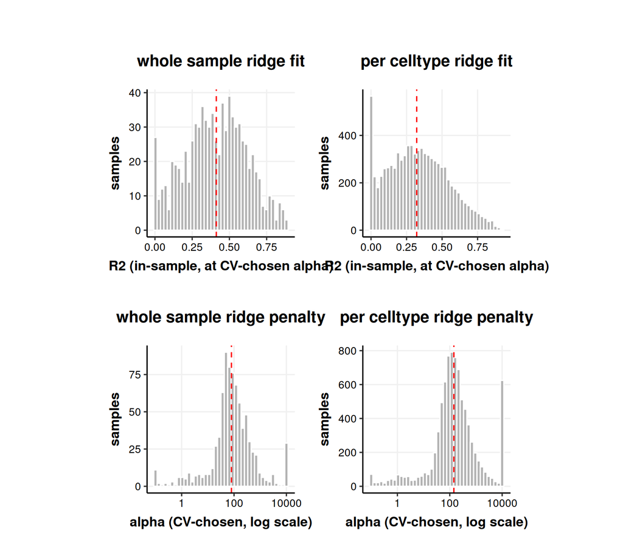

```r
(plot_model_fit("inflammation_atlas", "whole sample") +
  plot_model_fit("inflammation_atlas_celltypeLevel2", "per celltype")) /
  (plot_alpha_fit("inflammation_atlas", "whole sample") +
  plot_alpha_fit("inflammation_atlas_celltypeLevel2", "per celltype"))
```

Per-celltype samples are averaged over fewer cells, so their component scores are noisier and the ridge fit is correspondingly weaker – worth remembering when reading the celltype panels below.

# Disease associations

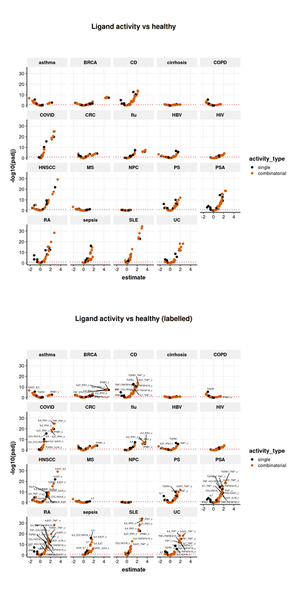

```r
plot_volcano(res_disease, facet = "contrast", label = FALSE,
             title = "Ligand activity vs healthy") /
  plot_volcano(res_disease, facet = "contrast",
               title = "Ligand activity vs healthy (labelled)")
```

```r
save_plot("inflammation_atlas_disease_volcano")
```

# Cross-disease heatmaps

For a given celltype, every disease’s activity estimates side by side. Estimates are scaled within disease (so diseases with more patients do not dominate) and masked where `padj >= 0.1`. Rows are clustered once across all panels so activities stay on the same row in each.

```r
heatmap_across_celltypes <- function(celltypes, vmin = -2.5, vmax = 2.5) {
  panels <- map(celltypes, function(target) {
    df <- res_level2 %>%
      filter(celltype == target) %>%
      annotate_results(annotations) %>%
      group_by(contrast) %>%
      mutate(estimate_scaled = as.vector(scale(estimate, center = FALSE))) %>%
      ungroup()

    to_matrix <- function(value_col, fill) {
      df %>%
        select(name, contrast, all_of(value_col)) %>%
        pivot_wider(names_from = contrast, values_from = all_of(value_col),
                    values_fill = fill) %>%
        column_to_rownames("name") %>%
        as.matrix() %>%
        replace(!is.finite(.), fill)
    }

    estimates <- to_matrix("estimate_scaled", 0)
    padj <- to_matrix("padj", 1)[rownames(estimates), colnames(estimates), drop = FALSE]
    list(estimates = estimates, padj = padj)
  })
  names(panels) <- celltypes

  # one row order for every panel
  row_dend <- as.dendrogram(hclust(dist(do.call(cbind, map(panels, "estimates"))),
                                   method = "ward.D2"))
  groups <- unique(disease_groups$diseaseGroup)
  group_colors <- setNames(brewer.pal(max(3, length(groups)), "Set1")[seq_along(groups)], groups)
  color_scale <- colorRamp2(seq(vmin, vmax, length.out = 9), rev(brewer.pal(9, "RdBu")))

  heatmaps <- imap(panels, function(panel, target) {
    masked <- panel$estimates
    masked[panel$padj >= SIG_CUTOFF] <- NA
    last <- target == celltypes[length(celltypes)]

    Heatmap(masked,
            name = "disease-scaled\nestimate",
            col = color_scale,
            top_annotation = HeatmapAnnotation(
              DiseaseGroup = disease_groups$diseaseGroup[match(colnames(masked),
                                                               disease_groups$disease)],
              col = list(DiseaseGroup = group_colors),
              show_legend = target == celltypes[1]),
            cluster_rows = row_dend,
            cluster_columns = as.dendrogram(hclust(dist(t(panel$estimates)), method = "ward.D2")),
            na_col = "grey90", border = TRUE,
            rect_gp = gpar(col = "white", lwd = 1),
            column_title = target,
            show_row_names = last,
            show_heatmap_legend = last)
  })

  reduce(heatmaps, `+`)
}
```

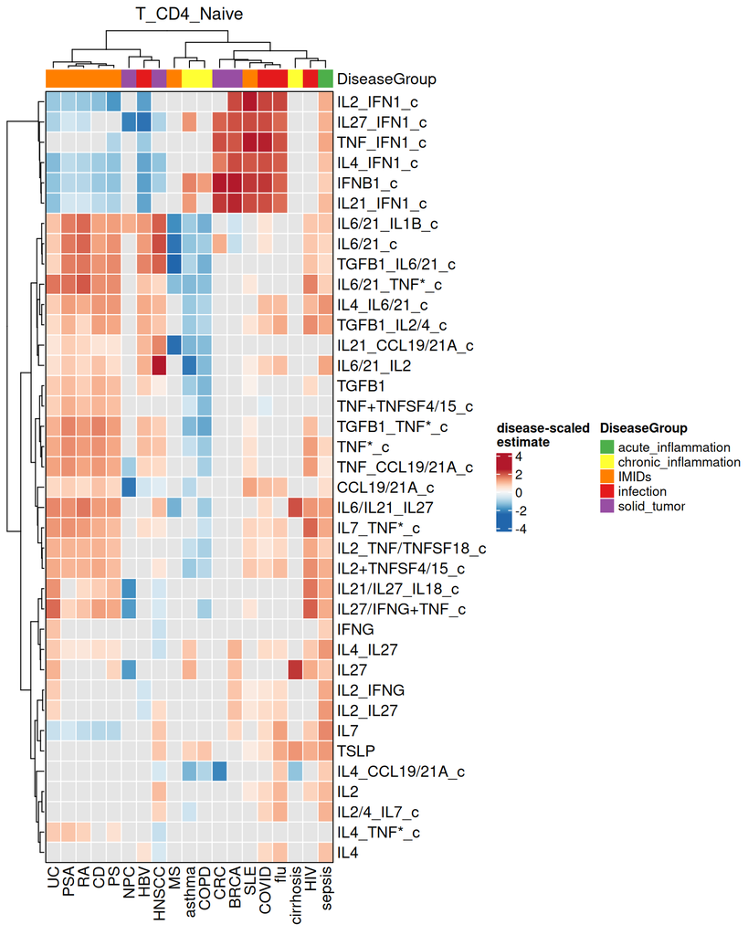

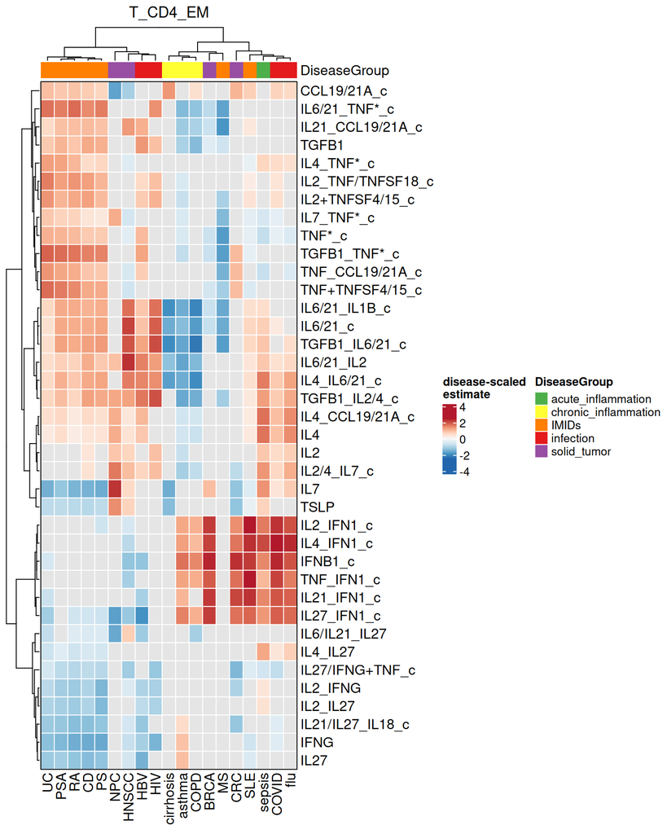

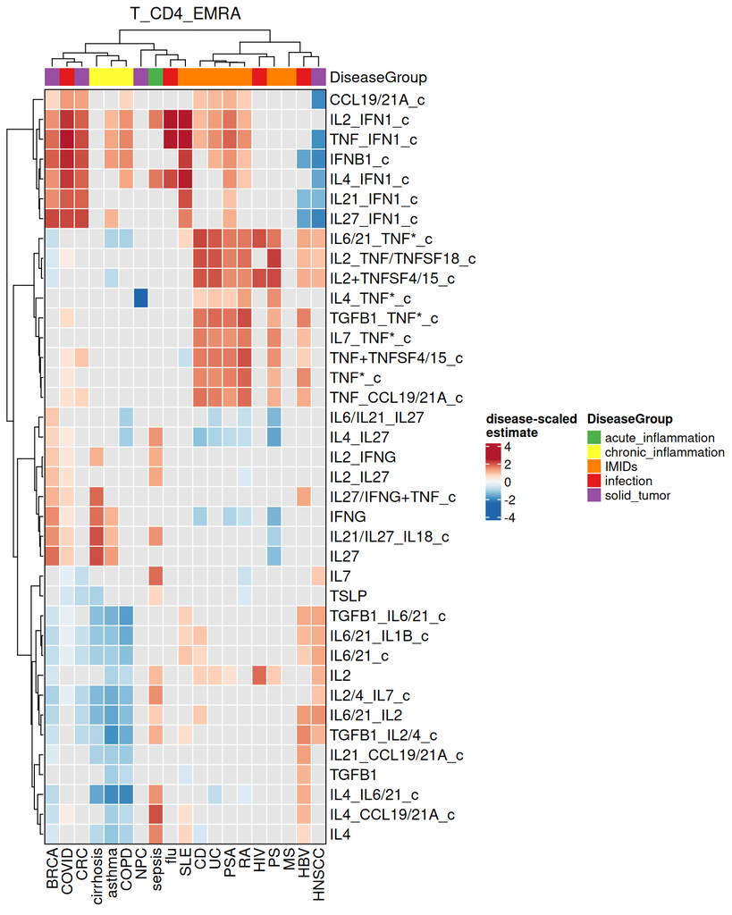

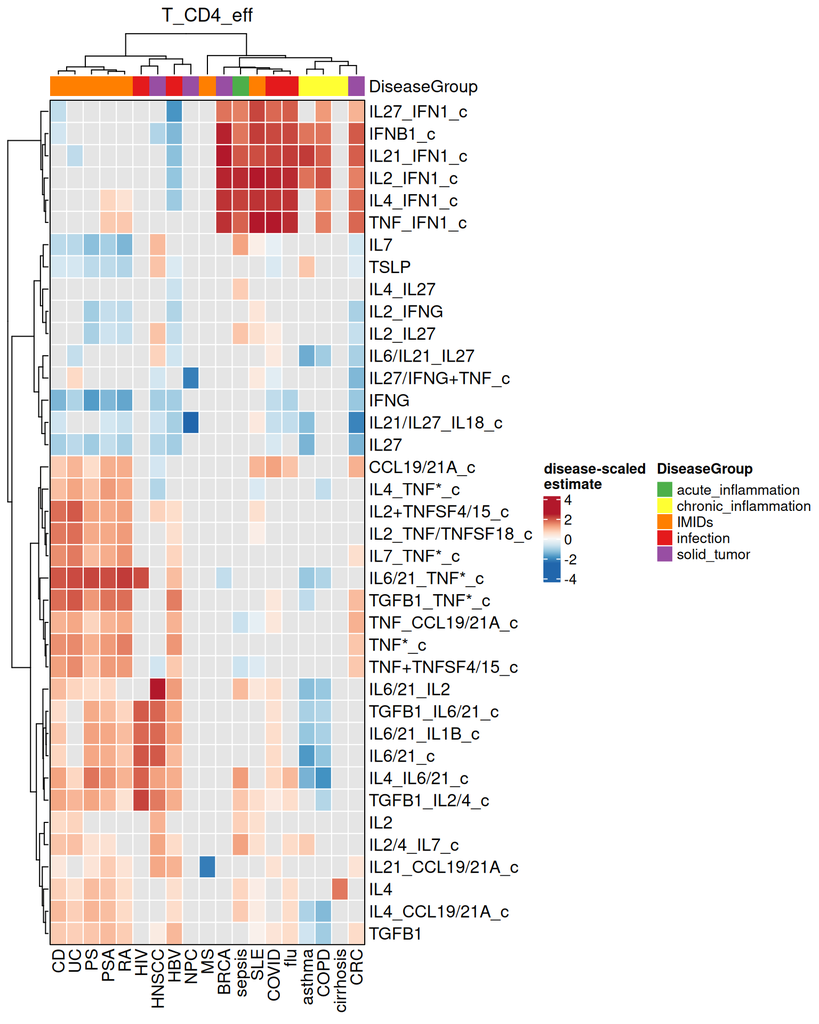

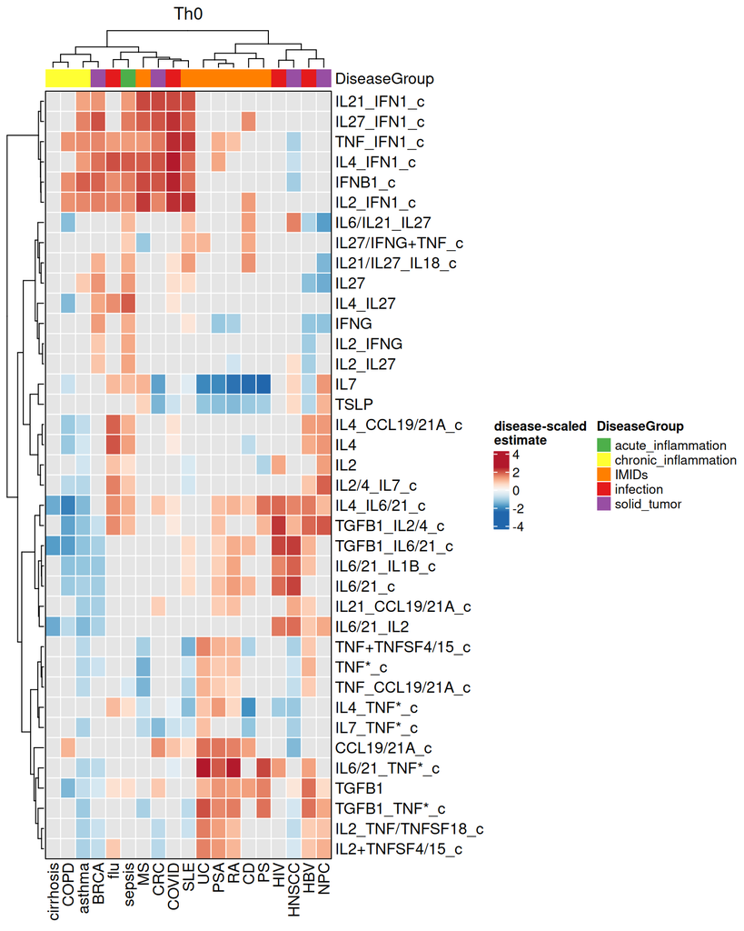

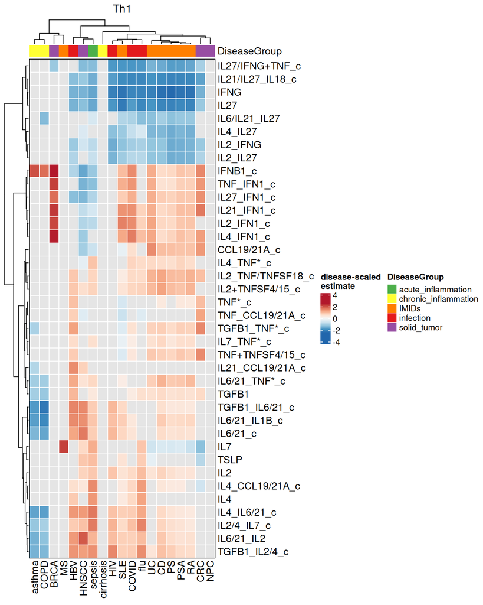

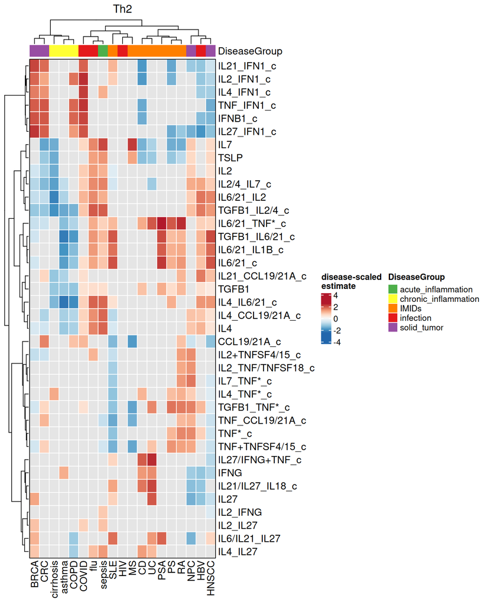

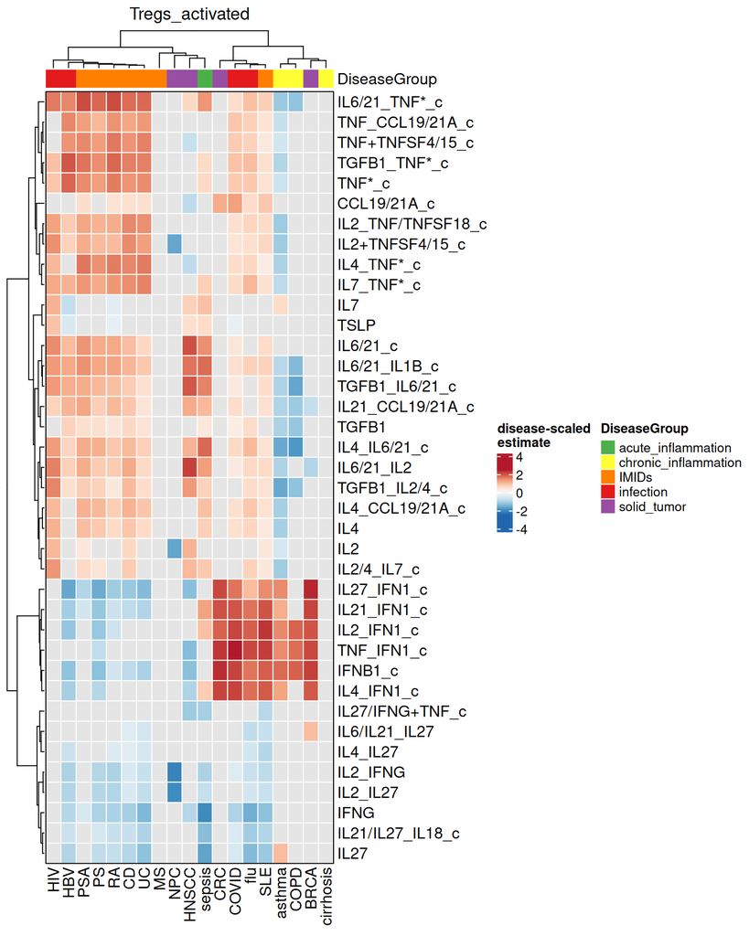

```r
walk(c("T_CD4_Naive", "T_CD4_EM", "T_CD4_EMRA", "T_CD4_eff",
       "Th0", "Th1", "Th2", "Tregs_activated"),
     ~ draw(heatmap_across_celltypes(.x)))
```

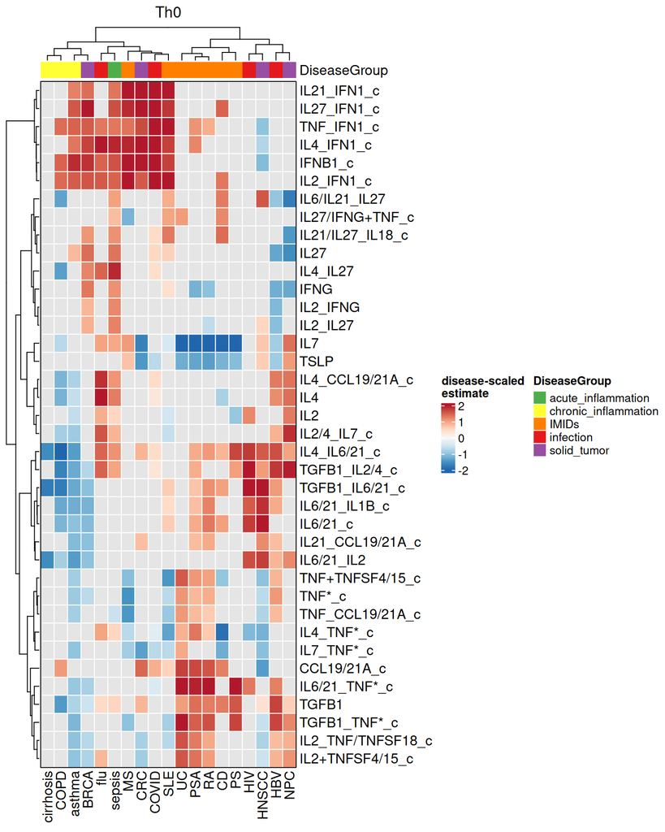

```r
draw(heatmap_across_celltypes("Th0", vmin = -2, vmax = 2))
```

```r
pdf(file.path(PLOT_DIR, "inflammation_atlas_cross_Th0.pdf"))
draw(heatmap_across_celltypes("Th0", vmin = -2, vmax = 2))
dev.off()
```

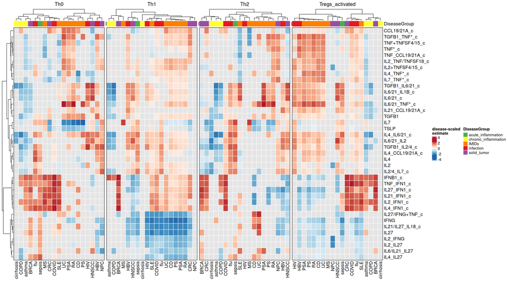

```r
TH_CELLTYPES <- c("Th0", "Th1", "Th2", "Tregs_activated")
draw(heatmap_across_celltypes(TH_CELLTYPES))
```

```r
pdf(file.path(PLOT_DIR, "inflammation_atlas_cross_celltype.pdf"))
draw(heatmap_across_celltypes(TH_CELLTYPES))
dev.off()
```

# Activity families across celltypes

TNF-family activities in the immune-mediated inflammatory diseases: is the shift concentrated in a particular helper subset?

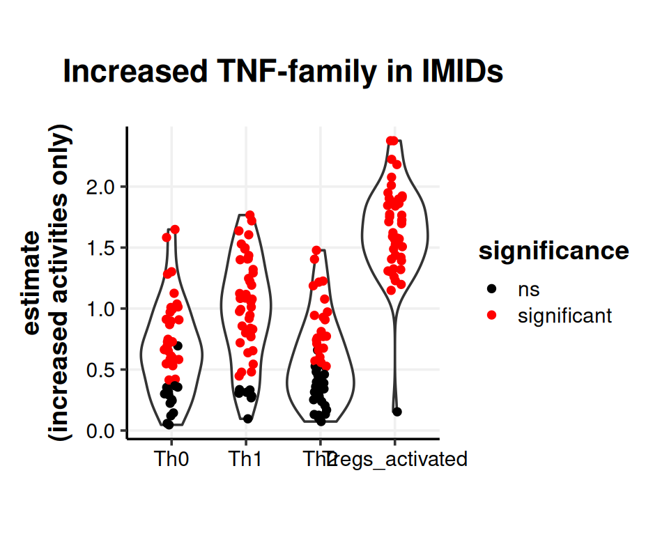

```r
AUTOIMMUNE <- c("PS", "PSA", "CD", "UC", "RA")

res_level2 %>%
  annotate_results(annotations) %>%
  filter(str_detect(component, "TNF"), contrast %in% AUTOIMMUNE,
         celltype %in% TH_CELLTYPES, estimate > 0) %>%
  mutate(significance = ifelse(padj < SIG_CUTOFF, "significant", "ns")) %>%
  ggplot(aes(x = celltype, y = estimate)) +
  geom_violin() +
  geom_jitter(aes(color = significance), size = 1.5, width = 0.1) +
  scale_color_manual(values = c(ns = "black", significant = "red")) +
  theme(aspect.ratio = 1) +
  labs(title = "Increased TNF-family in IMIDs",
       y = "estimate\n(increased activities only)", x = "")
```

```r
save_plot("inflammation_atlas_TNF_activity_celltypes")
```

Interferon and IL27 activities, CD vs UC in Th0:

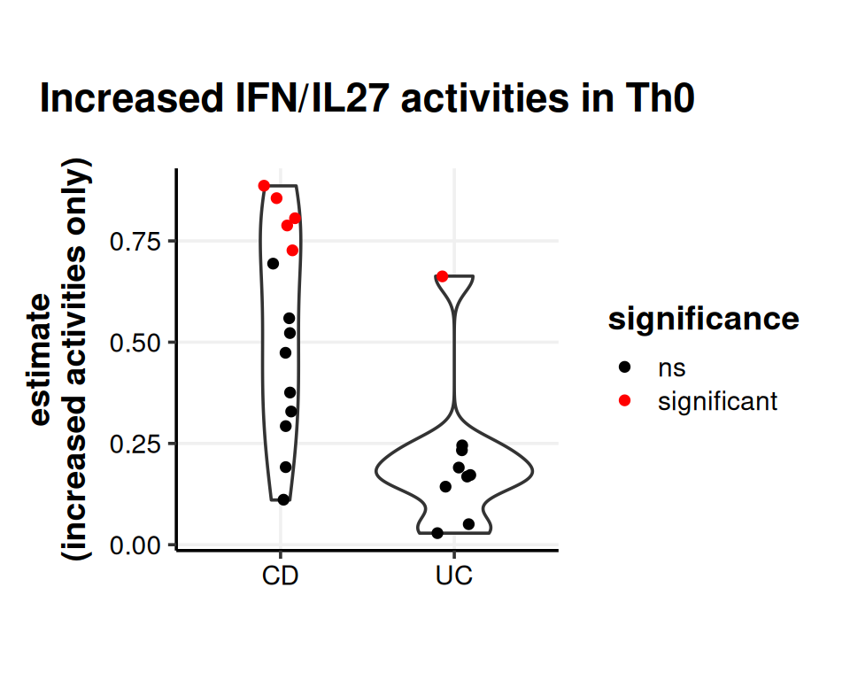

```r
res_level2 %>%
  annotate_results(annotations) %>%
  filter(str_detect(component, "IFNG|IL27|IFNA|IFNB1"),
         celltype == "Th0", contrast %in% c("CD", "UC"), estimate > 0) %>%
  mutate(significance = ifelse(padj < SIG_CUTOFF, "significant", "ns")) %>%
  ggplot(aes(x = contrast, y = estimate)) +
  geom_violin() +
  geom_jitter(aes(color = significance), size = 1.5, width = 0.1) +
  scale_color_manual(values = c(ns = "black", significant = "red")) +
  theme(aspect.ratio = 1) +
  labs(title = "Increased IFN/IL27 activities in Th0",
       y = "estimate\n(increased activities only)", x = "")
```

```r
save_plot("inflammation_atlas_IFN_activity_UC_CD")
```

# Combination vs single activities

Does a combination activity rise above the single-ligand activities it is built from? Estimates are scaled within disease x celltype, as in the heatmaps.

```r
scale_within_group <- function(res) {
  res %>%
    annotate_results(annotations) %>%
    left_join(disease_groups, by = c("contrast" = "disease")) %>%
    group_by(contrast, celltype) %>%
    mutate(estimate = as.vector(scale(estimate, center = FALSE))) %>%
    ungroup()
}

level2_scaled <- scale_within_group(res_level2)
level2_imid <- filter(level2_scaled, diseaseGroup == "IMIDs")
```

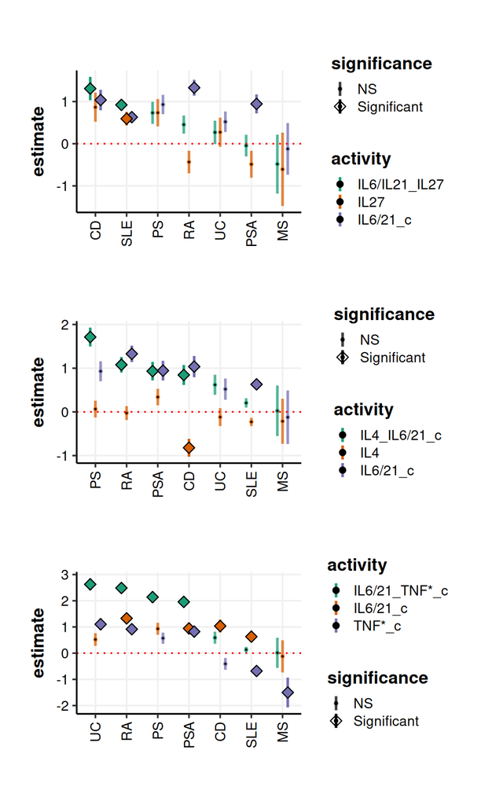

```r
th0_imid <- filter(level2_imid, celltype == "Th0")

plot_contrast_ranges(th0_imid, c("IL27_IL21_c", "IL27_c", "IL21_c")) /
  plot_contrast_ranges(th0_imid, c("IL4_IL21_c", "IL4_c", "IL21_c")) /
  plot_contrast_ranges(th0_imid, c("IL6_TNFSF18_c", "IL21_c", "TNFSF18_c"))
```

```r
save_plot("inflammation_atlas_combination_ranges_autoimmune", width = 5.5, height = 9)
```

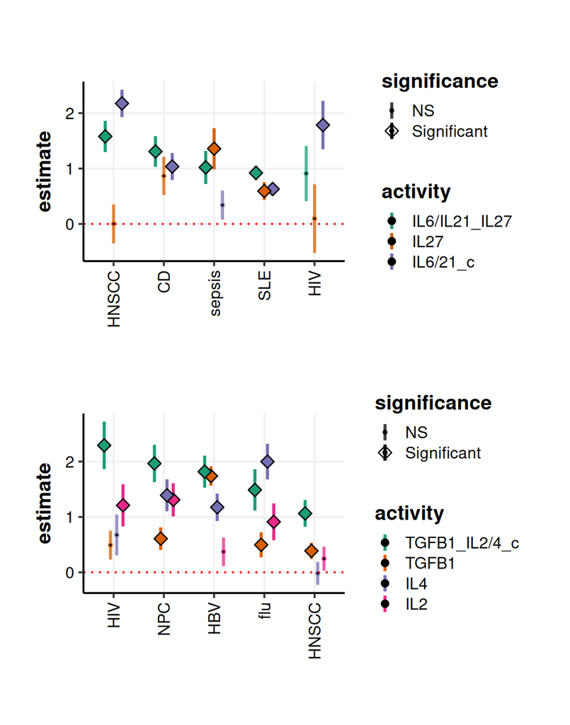

```r
th0_all <- filter(level2_scaled, celltype == "Th0")

plot_contrast_ranges(th0_all, c("IL27_IL21_c", "IL27_c", "IL21_c"), top_n = 5) /
  plot_contrast_ranges(th0_all, c("TGFB1_IL4_c", "TGFB1", "IL4_c", "IL2_c"), top_n = 5)
```

```r
save_plot("inflammation_atlas_combination_ranges_other", width = 5.5, height = 7)
```